# Practical 2: Dimension Reduction I

Nina van Gerwen (1860852)

2022-11-24

```r
library(dplyr)
```

```r
library(magrittr)
library(ggplot2)
```

## 2: Take home exercises

### 2.1: SVD and Eigendecomposition

```r
C <- read.table("Data/Example1.dat") %>%
  as.matrix(.) %>%
  scale(., scale = FALSE)
```

#### 2.2: Calculating sample size and covariance matrix

```r
N <- dim(C)[1]
S <- t(C) %*% C / N
```

#### 2.3: Obtaining the Singular Value Decomposition

```r
SVD <- svd(x = C)
```

#### 2.4: Inspecting the SVD

```r
U <- SVD$u
D <- SVD$d
V <- SVD$v
U
```

```
##              [,1]        [,2]
##  [1,] -0.26680000  0.28739123
##  [2,] -0.05470446 -0.33737580
##  [3,] -0.55896540 -0.13388431
##  [4,] -0.30683494 -0.23562992
##  [5,] -0.01466951  0.18564553
##  [6,]  0.19742603 -0.43912150
##  [7,]  0.48959143 -0.01784596
##  [8,]  0.02536542  0.70866669
##  [9,]  0.48959143 -0.01784596
```

```r
D
```

```
## [1] 31.219745  5.032642
```

```r
V
```

```
##           [,1]       [,2]
## [1,] 0.4289437  0.9033312
## [2,] 0.9033312 -0.4289437
```

Yes, the matrices are the same as on the slides!

#### 2.5: Calculating principal component scores

```r
lambda <- U * D
```

#### 2.6: Plotting the principal component scores

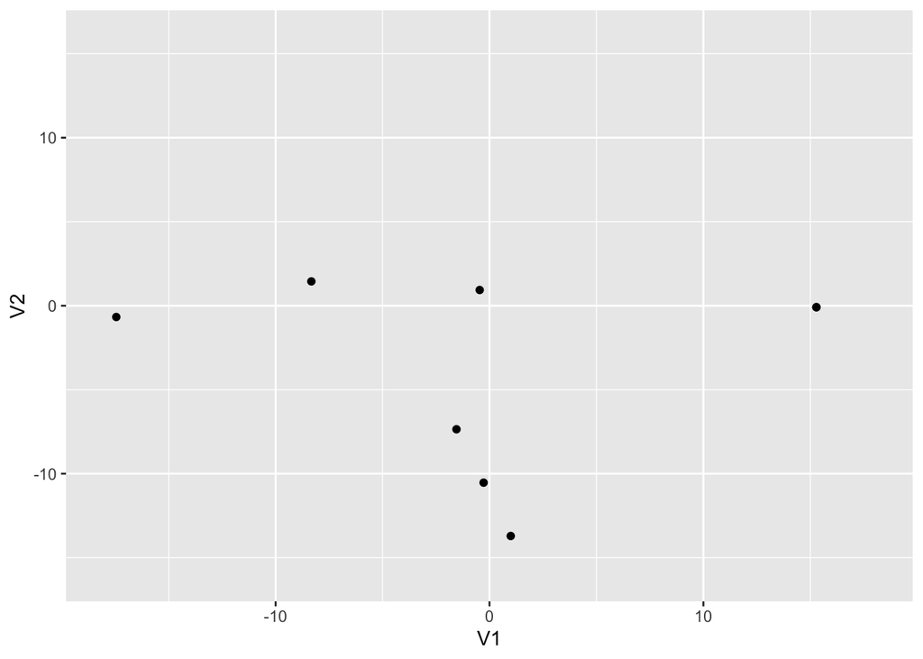

```r
lambda %>%
  as.data.frame(.) %>%
  ggplot(., aes(x = V1, y = V2)) +
  geom_point() +
  xlim(-18, 18) +
  ylim(-16, 16)
```

#### 2.7: Applying eigendecomposition

```r
EV <- eigen(S)
```

#### 2.8: Inspecting the eigenvalues

```r
sum(EV$values) == sum(diag(S))
```

```
## [1] TRUE
```

```r
sum((lambda[, 1] - mean(lambda[, 1]))^2) / 9
```

```
## [1] 93.70806
```

The sum of the eigenvalues are at least equal to the diagonal of the covariance matrix. However, the variance of the principle components seems to be somewhat different.

#### 2.9: Calculating percentage of total variance explained by each components

```r
EV$values[1] / sum(EV$values) * 100
```

```
## [1] 97.46725
```

```r
EV$values[2] / sum(EV$values) * 100
```

```
## [1] 2.532748
```

The first component explains 97.5% of the variance, and the second component explains the left-over 2.5% of the variance.

### 2.2: Principle Component Analysis

First we have to obtain the sample correlation matrix.

```r
SCM <- matrix(data = c(1, 0.32, 0.95, 0.94, 0.84, 0.22, 0.47, 0.82, 0.32, 1, 0.06,
                       0.21, 0.01, 0.30, 0.10, 0.01, 0.95, 0.06, 1, 0.94, 0.89, 0.14,
                       0.44, 0.81, 0.94, 0.21, 0.94, 1, 0.88, 0.19, 0.50, 0.68,
                       0.84, 0.01, 0.89, 0.88, 1, -0.23, 0.55, 0.63, 0.22, 0.30,
                       0.14, 0.19, -0.23, 1, -0.15, 0.21, 0.47, 0.10, 0.44, 0.50,
                       0.55, -0.15, 1, 0.14, 0.82, 0.01, 0.81, 0.68, 0.63, 0.21,
                       0.14, 1), nrow = 8, ncol = 8, byrow = TRUE)
SCM
```

```
##      [,1] [,2] [,3] [,4]  [,5]  [,6]  [,7] [,8]
## [1,] 1.00 0.32 0.95 0.94  0.84  0.22  0.47 0.82
## [2,] 0.32 1.00 0.06 0.21  0.01  0.30  0.10 0.01
## [3,] 0.95 0.06 1.00 0.94  0.89  0.14  0.44 0.81
## [4,] 0.94 0.21 0.94 1.00  0.88  0.19  0.50 0.68
## [5,] 0.84 0.01 0.89 0.88  1.00 -0.23  0.55 0.63
## [6,] 0.22 0.30 0.14 0.19 -0.23  1.00 -0.15 0.21
## [7,] 0.47 0.10 0.44 0.50  0.55 -0.15  1.00 0.14
## [8,] 0.82 0.01 0.81 0.68  0.63  0.21  0.14 1.00
```

#### 2.9: Applying PCA to the SCM

```r
PCA <- eigen(SCM)
```

#### 2.10: Interpreting through the greater-than-one rule

```r
sum(PCA$values > 1)
```

```
## [1] 3
```

Three principal components should be extracted according to this rule!

#### 2.11: Explained variance by the three components

```r
sum(PCA$values[1:3]) / sum(PCA$values) * 100
```

```
## [1] 88.94114
```

The first three principal components explain 88.9% of the total variance.

#### 2.12: Making a scree plot

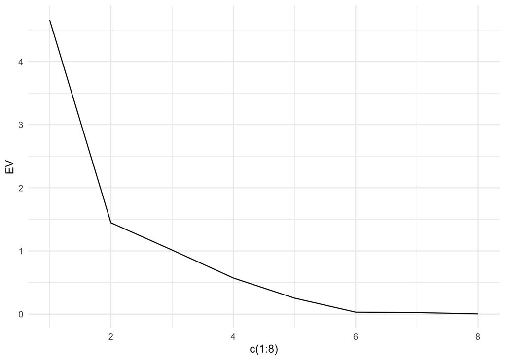

```r
PCA$values %>%
  data.frame(EV = .) %>%
  ggplot(., aes(x = c(1:8), y = EV)) +
  geom_line() + theme_minimal()
```

According to the scree-plot, you would only extract one principal components!

#### 2.13: Explained variance by the first principal component

```r
sum(PCA$values[1]) / sum(PCA$values) * 100
```

```
## [1] 58.18535
```

The first principal component explains 58.2% of the total variance.

## 3: Lab Exercises

```r
mtcars <- mtcars
```

```r
mtcars.pca <- prcomp(mtcars[, c(1:7, 10, 11)],
                     center = TRUE,
                     scale = TRUE)
```

#### 3.14: Inspecting the PCA

```r
summary(mtcars.pca)
```

```
## Importance of components:
##                           PC1    PC2     PC3     PC4     PC5     PC6     PC7
## Standard deviation     2.3782 1.4429 0.71008 0.51481 0.42797 0.35184 0.32413
## Proportion of Variance 0.6284 0.2313 0.05602 0.02945 0.02035 0.01375 0.01167
## Cumulative Proportion  0.6284 0.8598 0.91581 0.94525 0.96560 0.97936 0.99103
##                           PC8     PC9
## Standard deviation     0.2419 0.14896
## Proportion of Variance 0.0065 0.00247
## Cumulative Proportion  0.9975 1.00000
```

#### 3.15: Explained variances by PC1

The summary function showed that the proportion of variance explained by PC1 is 62.8%.

#### 3.16.1: Cumulative explained variance by PC1, PC2 and PC3

The summary function showed that the cumulative proportion of variance explained by the first three components is 91.6%.

#### 3.16.2: Determining the eigenvalues

```r
eigen(cov(scale(mtcars)))$values
```

```
##  [1] 6.60840025 2.65046789 0.62719727 0.26959744 0.22345110 0.21159612
##  [7] 0.13526199 0.12290143 0.07704665 0.05203544 0.02204441
```

According to the greater-than-one rule, we should extract only the first two principal components.

#### 3.18: Explained variance by P1 and P2

If we extract only the first two principal components, the cumulative proportion of explained variance is 86%.

#### 3.19: Creating a biplot for the first two PC

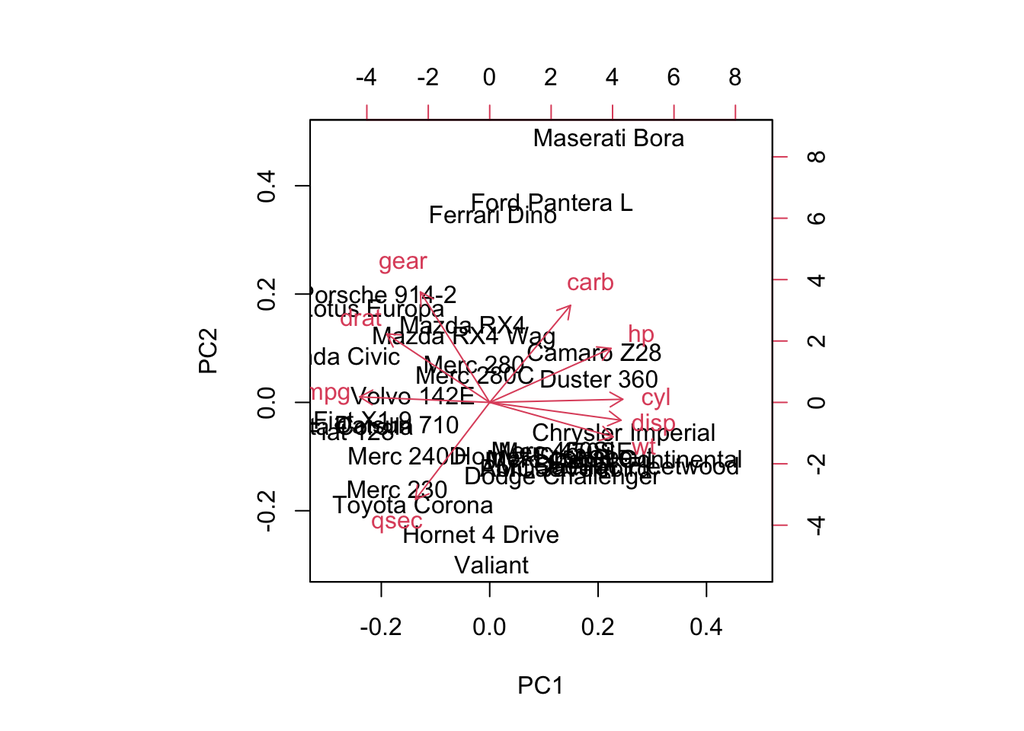

```r
biplot(mtcars.pca, choices = c(1,2))
```

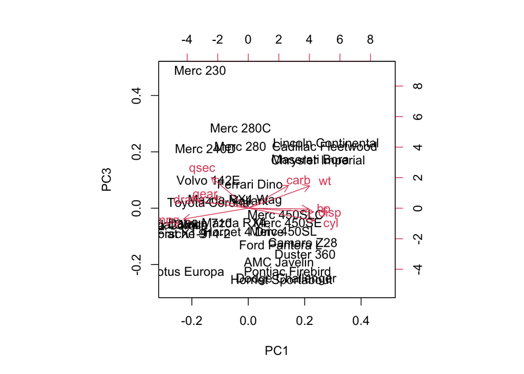

```r
biplot(mtcars.pca, choices = c(1,3))
```

From this plot, we can see that the car brand that has exceptional positive values on PC3, and negative positive values on PC1 is *Merc 230*.

#### 3.21: Creating and interpreting the screeplot

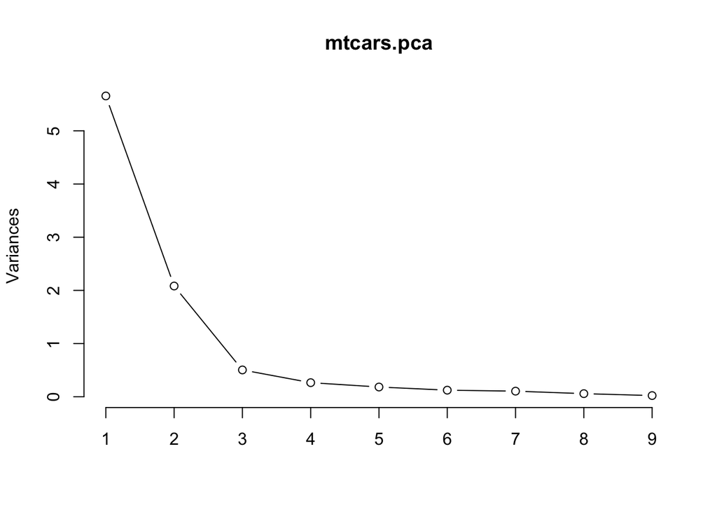

```r
screeplot(mtcars.pca, type = "lines")
```

Interpreting this plot, I would argue the screeplot states that you should extract either 1 or 2 principal components (because both the second and third component can be seen as an ‘elbow’). If you were to choose 2, this would be in agreement with the eigenvalues-greater-than-one rule. Taking these results together, I would therefore choose the first 2 PC.